# Actividad 2: nálisis descriptivo e inferencial

Gonzalo Mellizo-Soto Díaz

# 1. Carga de los datos

**Cargar el archivo de datos “Fumadores_clean_5Y.csv” y validar que los tipos de datos se interpretan correctamente.**

Cargamos los datos iniciales y comprobamos los tipos

|  | Sex | Sport | Years | Cig | PC | City | Weight | Age | Height | PC5Y |
| --- | --- | --- | --- | --- | --- | --- | --- | --- | --- | --- |
| 1 | M | E | 25 | 10 | 2.579 | Barcelona | 65 | 49 | 171 | 2.529 |
| 2 | F | E | 18 | 32 | 1.557 | Terrassa | 65 | 35 | 166 | 1.444 |
| 3 | M | S | 0 | 0 | 3.747 | La Bisbal | 69 | 38 | 175 | 3.730 |
| 4 | M | N | 25 | 14 | 2.762 | Blanes | 70 | 55 | 176 | 2.670 |
| 5 | M | E | 0 | 0 | 3.487 | Sant Boi de Llobregat | 72 | 55 | 178 | 3.487 |
| 6 | F | S | 0 | 0 | 4.075 | Barcelona | 64 | 42 | 165 | 4.052 |

```r
str(fumadoresClean)
```

```
'data.frame':   300 obs. of  10 variables:
 $ Sex   : Factor w/ 2 levels "F","M": 2 1 2 2 2 1 2 2 2 2 ...
 $ Sport : Factor w/ 4 levels "E","N","R","S": 1 1 4 2 1 4 1 1 1 1 ...
 $ Years : int  25 18 0 25 0 0 33 0 0 5 ...
 $ Cig   : int  10 32 0 14 0 0 15 0 0 12 ...
 $ PC    : num  2.58 1.56 3.75 2.76 3.49 ...
 $ City  : Factor w/ 20 levels "Alcanar","Barcelona",..: 2 18 8 3 14 2 18 18 2 2 ...
 $ Weight: int  65 65 69 70 72 64 69 71 72 73 ...
 $ Age   : int  49 35 38 55 55 42 55 44 45 35 ...
 $ Height: int  171 166 175 176 178 165 175 177 178 179 ...
 $ PC5Y  : num  2.53 1.44 3.73 2.67 3.49 ...
```

Vemos como los datos se cargan correctamente y los factores son expresados como tal (se podría mantener el ordinal realizado en la práctica anterior) y como las variable numéricas se convierten bien a integer o double según la necesidad.

# 2. Estadística descriptiva

**En primer lugar, estudiaremos los valores centrales y de dispersión de algunas variables del conjunto de datos. Siga los pasos que se especifican a continuación**

## 2.1 Valores centrales

**Media, mediana y los cinco números (de Tukey) de la capacidad pulmonar.**

```r
print(paste("La media de la capacidad pulmonar es: ",
            mean(fumadoresClean$PC)))
```

```
[1] "La media de la capacidad pulmonar es:  3.33099"
```

```r
print(paste("La mediana de la capacidad pulmonar es: ",
            median(fumadoresClean$PC)))
```

```
[1] "La mediana de la capacidad pulmonar es:  3.554"
```

```r
print("El resumen de los cinco números es: ")
```

```
[1] "El resumen de los cinco números es: "
```

```r
summary(fumadoresClean$PC)
```

```
   Min. 1st Qu.  Median    Mean 3rd Qu.    Max.
  1.557   2.908   3.554   3.331   3.793   4.466
```

El punto medio sería la media entre el punto 150 y 151 del vector (ordenado), en este caso coincidiendo con la mediana. El summary también muestra la media por lo que se podría realizar en un simple comando.

**Visualizar la muestra de valores en un diagrama de caja (boxplot)**

Para la visualización utilizaremos ggplot2

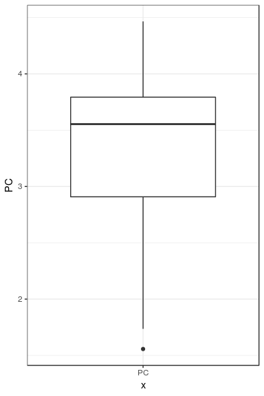

```r
ggplot(data = fumadoresClean, aes(x = 'PC', y = PC))+
  geom_boxplot()+
  theme_bw()
```

**¿Se detectan valores extremos (outliers) en el diagrama?**

Si, se detecta un valor atípico, el valor mínimo de 1.557.

** A continuación, mostrar mediante diagramas de caja la capacidad pulmonar separando el género femenino y el masculino**

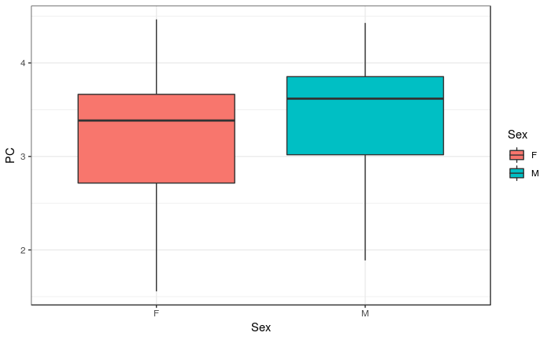

```r
ggplot(fumadoresClean, aes(x = Sex, y = PC, fill = Sex))+
  geom_boxplot()+
  theme_bw()
```

Se puede apreciar como la capacidad pulmonar es mayor y ligeramente menos dispersa para el género masculino.

**Mostrar, finalmente, mediante diagramas de caja la comparación entre el valor de PC original y al cabo de 5 años. Interpretar los resultados.**

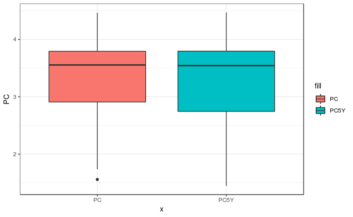

```r
ggplot(data = fumadoresClean) +
  geom_boxplot(aes(x = 'PC', y = PC, fill = "PC"))+
  geom_boxplot(aes(x = "PC5Y", y = PC5Y, fill = "PC5Y"))+
  theme_bw()
```

Según la distribución de las cajas, podemos concluir con que a los 5 años se muestran valores más dispersos, por ejemplo, el valor atípico tras los cinco años deja de serlo.

La mediana se mantiene estable (ligeramente más baja), mientras que los valores entre el primer cuartil y la mediana son más dispersos que en la toma inicial.

## 2.2 Dispersión

**Calcular la dispersión de la capacidad pulmonar usando las medidas: varianza, desviación típica y rango intercuartílico.**

Las medidas de dispersión son las siguientes:

```r
print(paste("La varianza es:",  var(fumadoresClean$PC)))
```

```
[1] "La varianza es: 0.393775086856187"
```

```r
print(paste("La desviación típica es:", sd(fumadoresClean$PC)))
```

```
[1] "La desviación típica es: 0.627515009267657"
```

```r
print(paste("El rango intercuartílico es:", IQR(fumadoresClean$PC)))
```

```
[1] "El rango intercuartílico es: 0.88475"
```

## 2.3 Cálculo manual de la dispersión

**Calcular la desviación típica de la capacidad pulmonar manualmente y comparar el resultado con la función correspondiente de R.**

Implementamos manualmente la función:

```r
sqrt(sum((fumadoresClean$PC - mean(fumadoresClean$PC))^2)/ (length(fumadoresClean$PC)))
```

```
[1] 0.6264683
```

Existe una diferencia y es que la función de R utiliza la varianza muestral, N-1 en lugar de N:

```r
sqrt(sum((fumadoresClean$PC - mean(fumadoresClean$PC))^2)/ (length(fumadoresClean$PC) - 1))
```

```
[1] 0.627515
```

## 2.4 Histograma

**Representar un histograma de la variable PC. Si es necesario, configura los parámetros del histograma para que se vea con una buena precisión.**

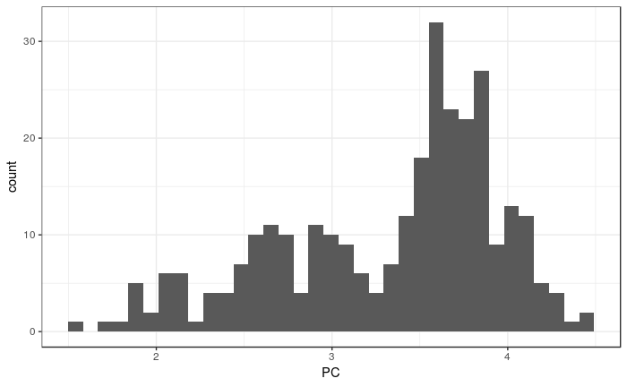

```r
ggplot(fumadoresClean, aes(x=PC))+
  geom_histogram(bins = 35)+
  theme_bw()
```

Este gráfico nos ayuda a comprender la distribución de los datos, en este caso se observa claramente como la mayoría de datos se encuentran comprendidos entre los valores 3 y 4.

## 2.5 Datos categóricos

**En las variables Sex, Sport y City, realizar un resumen numérico y dibujar un diagrama circular que muestre la proporción de casos de cada categoria**

```r
print("El resumen numérico de 'Sex' es:")
```

```
[1] "El resumen numérico de 'Sex' es:"
```

```r
print(summary(fumadoresClean$Sex))
```

```
  F   M
137 163
```

```r
print("El resumen numérico de 'Sport' es:")
```

```
[1] "El resumen numérico de 'Sport' es:"
```

```r
print(summary(fumadoresClean$Sport))
```

```
  E   N   R   S
127  83  48  42
```

```r
print("El resumen numérico de 'City' es:")
```

```
[1] "El resumen numérico de 'City' es:"
```

```r
print(summary(fumadoresClean$City))
```

```
              Alcanar             Barcelona                Blanes              Cadaques
                   12                   102                    11                     2
             Cardedeu               Cardona                Girona             La Bisbal
                    3                     6                    10                     7
               Lleida               Montgat         Pineda de Mar             Puigcerda
                   13                     6                    11                     3
               Ripoll Sant Boi de Llobregat                Sitges               Solsona
                    6                    12                    13                     5
            Tarragona              Terrassa                 Tossa                 Valls
                   14                    42                     7                    15
```

Los diagramas de cada uno son los siguientes:

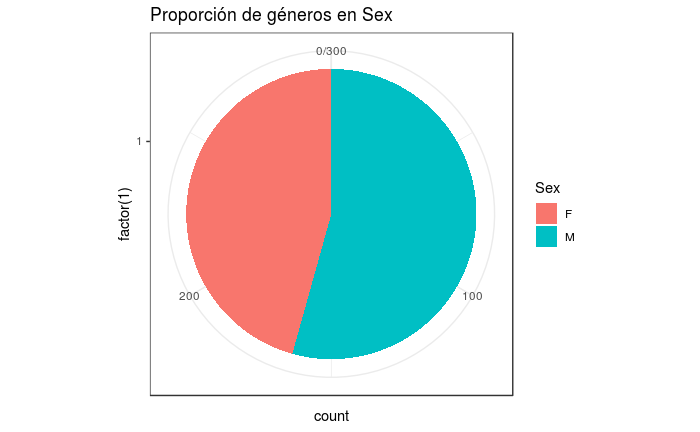

```r
ggplot(fumadoresClean)+
  geom_bar(aes(x = factor(1), fill = Sex), width = 1)+
  ggtitle('Proporción de géneros en Sex')+
  coord_polar('y')+
  theme_bw()
```

Se observa como la mayor parte de los fumadores son hombres.

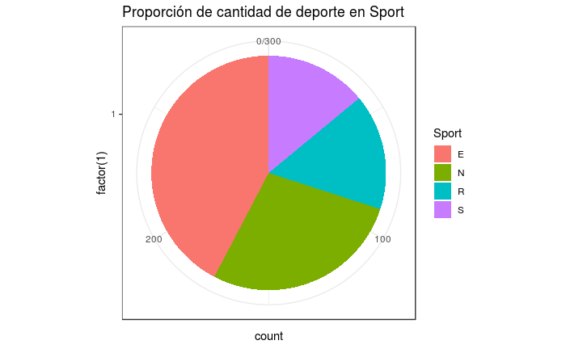

```r
ggplot(fumadoresClean)+
  geom_bar(aes(x = factor(1), fill = Sport), width = 1)+
  ggtitle('Proporción de cantidad de deporte en Sport')+
  coord_polar('y')+
  theme_bw()
```

Se oberva claramente como la mayor parte realiza ejercicio todos los días y en segundo puesto los que no se ejercitan.

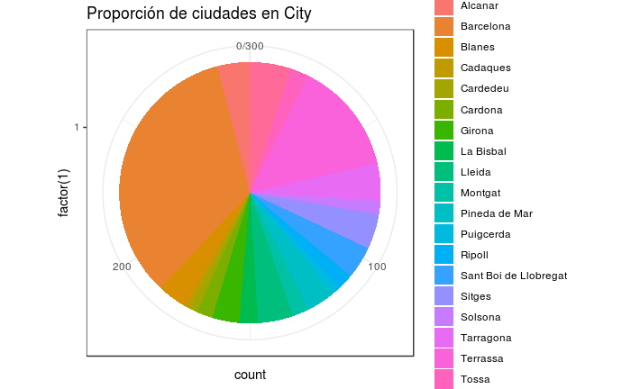

```r
ggplot(fumadoresClean)+
  geom_bar(aes(x = factor(1), fill = City), width = 1)+
  ggtitle('Proporción de ciudades en City')+
  coord_polar('y')+
  theme_bw()
```

Se observa claramente la mayor participación de personas de Barcelona (mayor densidad poblacional) y de Terrasa

# 3. Estadística inferencial

## 3.1 Intervalo de confianza

**Calcular el intervalo de confianza del 97 % de la capacidad pulmonar de la población.**

**Nota: Se deben realizar los cálculos manualmente. No se pueden usar funciones de R que calculen directamente el intervalo de confianza como t.test o similar. Si que podeis usar funciones como qnorm, pnorm , qt y pt.**

Fijamos los parámetros y calculamos

```r
intervalo <- 0.97
s <- sd(fumadoresClean$PC)
errorSd <- s/sqrt(length(fumadoresClean$PC))
valorCritico <- (1-intervalo)/2
tValue <- qt(c(valorCritico, 1-valorCritico), df=(length(fumadoresClean$PC)-1))
margenError <- tValue * errorSd
inicioIntervalo <- mean(fumadoresClean$PC) + margenError[1]
finIntervalo <- mean(fumadoresClean$PC) + margenError[2]
print(paste0("El intervalo de confianza es: [", inicioIntervalo, ',', finIntervalo, ']'))
```

```
[1] "El intervalo de confianza es: [3.25199145080875,3.40998854919125]"
```

## 3.2 Analizar la capacidad pulmonar de las mujeres

**Asumimos que conocemos la capacidad pulmonar media de la población, que es igual a 3.30. ¿Podemos decir que la capacidad pulmonar de las mujeres es inferior a la media poblacional, con un nivel de confianza del 95 %? Para responder a esta pregunta, siga los pasos que se indican.**

**Nota: Se deben realizar los cálculos manualmente. No se pueden usar funciones de R que calculen directamente el intervalo de confianza como t.test o similar. Si que podeis usar funciones como qnorm, pnorm , qt y pt.**

### 3.2.1 Escribir la hipótesis nula y alternativa

- La hipótesis nula H0 es: “La media poblaciona es igual a 3.30” meanPC = 3.30
- La hipótesis alternativa (unilateral) es: “La capacidad pulmonar de las mujeres es menor a la media poblacional” meanPC(mujeres) < 3.30

### 3.2.2 Método

**Indicar cuál es el método más apropiado para hacer este análisis, en función de las características de la muestra y el objetivo del análisis.**

En este caso se utilizara un método de contraste entre las medias de las poblaciones, basado en el p-valor para rechazar o aceptar la hipótesis nula.